#### Appendix 1 - Search String

We entered the following search terms into the Web of Science and Aquatic Commons databases on February 19, 2014: (marine OR ocean* OR benthic* OR coral OR kelp* OR seamount OR vent OR mangrove OR “sea grass” OR seagrass OR plankton OR “deep sea” OR abyss* OR pelagic OR beach OR intertid* OR “salt marsh” OR “soft sediment” OR mudflat OR “mud flat” OR benthos OR “sub-tidal*” OR subtidal* OR “sub-littoral” OR sublittoral* OR macrobenthos OR estuar*) AND (biodiv* OR divers* OR richness OR evenness OR “community composition” OR “food web” OR “benthic communit*” OR “pelagic communit*”) AND (resurvey* OR resampl* OR “time series” OR “temporal change” OR decad* OR annual* OR multiyear OR “multi-year” OR “multi-decade” OR revisit*) NOT (fossil OR geologic* OR freshwater OR terrestrial OR grassland)

#### Appendix 2 - Figures and Tables

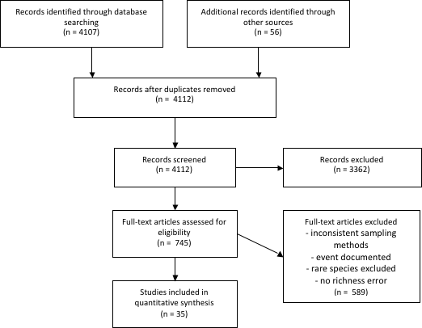

**Figure S1.** Preferred Reporting Items for Systematic reviews and Meta-Analysis (PRISMA) diagram depicting the study selection process.

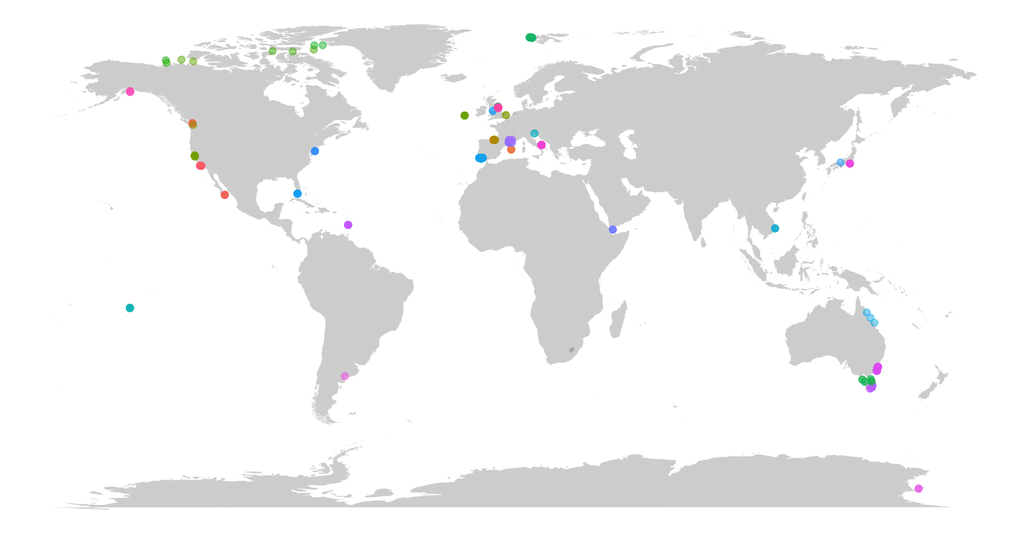

**Figure S2.** Global distribution of sites (k = 144) included in the meta-analysis with unique studies (n = 35) indicated by colour.

**Table S1.** Standardised parameter estimates from three variance-weighted meta-regressions of the log ratio of the proportion of species richness change (LR). For each parameter estimate the number of studies (n), number of sites (k), p-value (pval), lower and upper 95% confidence intervals are included. The percent change (% change) has been back-calculated from the estimated log ratio of the proportion of change in species richness. Each study could contain multiple sites and therefore studies were modeled as random effects.

| model | n | k | parameter | estimate | % change | pval | lower CI | upper CI |
| --- | --- | --- | --- | --- | --- | --- | --- | --- |
| LR ~ Dur | 34 | 142 | Int | -0.046 | -4.5000 | 0.425 | -0.16 | 0.07 |
|  |  |  | Dur | 0.011 | 1.1200 | 0.024 | 0.00 | 0.02 |
| LR ~ CHI + Dur + Dur*CHI | 32 | 133 | Int | 0.205 | 22.7300 | 0.129 | -0.06 | 0.47 |
|  |  |  | Dur | -0.033 | -3.2400 | 0.004 | -0.06 | -0.01 |
|  |  |  | CHI | -0.047 | -4.6300 | 0.081 | -0.10 | 0.01 |
|  |  |  | Dur:CHI | 0.009 | 0.8600 | 0.000 | 0.00 | 0.01 |
| LR ~ Dur * (Inv + Nut + LTC) | 23 | 110 | Int | -0.015 | -1.5070 | 0.883 | -0.22 | 0.19 |
|  |  |  | Dur | 0.017 | 1.7124 | 0.027 | 0.00 | 0.03 |
|  |  |  | Inv | -1.550 | -0.0014 | 0.066 | -3.20 | 0.10 |
|  |  |  | LTC | 0.147 | 6.0097 | 0.018 | 0.03 | 0.27 |
|  |  |  | Nut | 0.782 | 1.3255 | 0.007 | 0.22 | 1.35 |
|  |  |  | Dur:Inv | 0.136 | 0.0001 | 0.016 | 0.02 | 0.25 |
|  |  |  | Dur:LTC | -0.069 | -2.6855 | 0.036 | -0.13 | 0.00 |
|  |  |  | Dur:Nut | -0.116 | -0.1959 | 0.004 | -0.20 | -0.04 |

**Table S2.** Rate of the percent change of species richness across the five most sampled taxonomic groups using variance-weighted meta-regressions: mixed (more than one taxonomic group), fish, algae, invertebrates, and zooplankton. The table includes the number of unique studies, sites, and duration of the longest running study. Upper (upper ci) and lower (lower ci) confidence intervals for the percent change are also included and number of stars indicate level of significance.

| taxa | studies | sites | max duration | percent change | pval | lower ci | upper ci | sig |
| --- | --- | --- | --- | --- | --- | --- | --- | --- |
| mixed | 7 | 22 | 41 | 0.957 | 0.153 | -0.353 | 2.285 |  |
| fish | 11 | 47 | 28 | -0.528 | 0.422 | -1.805 | 0.765 |  |
| algae | 4 | 33 | 17 | 5.463 | 0.000 | 2.489 | 8.523 | *** |
| zooplankton | 4 | 6 | 36 | 0.122 | 0.938 | -2.929 | 3.269 |  |
| inverts | 10 | 35 | 19 | 8.153 | 0.000 | 4.623 | 11.802 | *** |

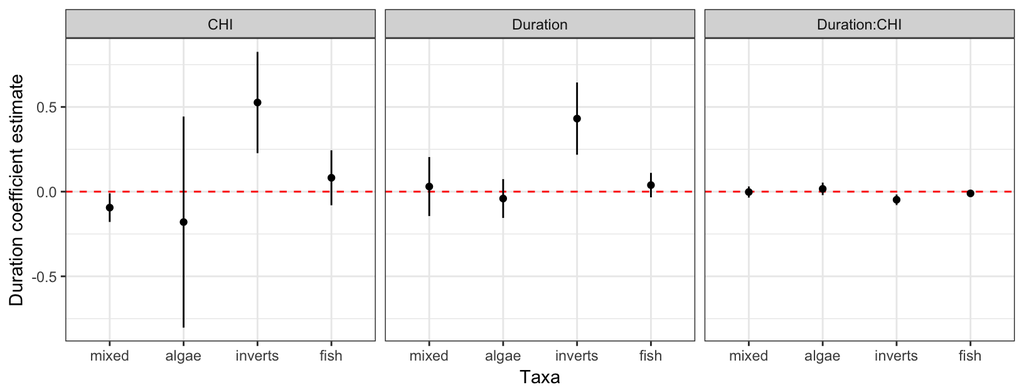

**Figure S3.** Coefficient estimates of the log-proportion of species richness change as moderated by cumulative human impact values (CHI) in the four most sampled taxonomic groups. Points represent coefficient estimates and lines represent 95% confidence intervals using variance-weighted meta-regressions.

| Taxa | Model | Log-Likelihood | K | Deviance | AICc | Delta AICc | Akaike weight |
| --- | --- | --- | --- | --- | --- | --- | --- |
|  | LR ~ Dur | -22.93 | 1 | 94.30 | 53.36 | 0.08 | 0.98 |
| mixed | LR ~ Dur + CHI + Dur*CHI | -19.50 | 3 | 87.44 | 53.28 | 0.00 | 1.00 |
|  | LR ~ Dur | -39.80 | 1 | 152.83 | 91.14 | 2.08 | 0.46 |
| fish | LR ~ Dur + CHI + Dur*CHI | -41.24 | 3 | 155.71 | 89.06 | 0.00 | 1.00 |
|  | LR ~ Dur | -49.50 | 1 | 161.56 | 111.73 | 0.00 | 1.00 |
| algae | LR ~ Dur + CHI + Dur*CHI | -67.48 | 3 | 197.53 | 141.97 | 30.24 | 0.00 |
|  | LR ~ Dur | -2406.24 | 1 | 4896.99 | 4819.27 | 2.30 | 0.42 |
| inverts | LR ~ Dur + CHI + Dur*CHI | -2402.42 | 3 | 4889.35 | 4816.98 | 0.00 | 1.00 |

**Table S4.** The effect of cumulative human impact value (CHI) on the percent change and rate of percent change of species richness across the four most sampled taxonomic groups using variance-weighted meta-regressions: mixed (more than one taxonomic group), fish, algae, and invertebrates. The table includes the number of unique studies, sites, and duration of the longest running study. Upper (upper ci) and lower (lower ci) confidence intervals for the percent change are also included and number of stars indicate level of significance.

| taxa | studies | sites | max duration | parameter | percent change | pval | lower ci | upper ci | sig |
| --- | --- | --- | --- | --- | --- | --- | --- | --- | --- |
| algae | 3 | 28 | 17 | Dur | -3.987 | 0.487 | -14.384 | 7.674 |  |
|  |  |  |  | CHI | -16.443 | 0.572 | -55.191 | 55.815 |  |
|  |  |  |  | Dur:CHI | 1.662 | 0.380 | -2.011 | 5.473 |  |
| inverts | 10 | 34 | 19 | Dur | 53.908 | 0.000 | 24.341 | 90.507 | *** |
|  |  |  |  | CHI | 69.261 | 0.001 | 25.535 | 128.218 | *** |
|  |  |  |  | Dur:CHI | -4.683 | 0.003 | -7.614 | -1.659 | ** |
| fish | 11 | 45 | 12 | Dur | 3.937 | 0.294 | -3.299 | 11.715 |  |
|  |  |  |  | CHI | 8.536 | 0.322 | -7.713 | 27.645 |  |
|  |  |  |  | Dur:CHI | -1.025 | 0.155 | -2.421 | 0.391 |  |
| mixed | 6 | 20 | 41 | Dur | 3.063 | 0.734 | -13.408 | 22.667 |  |
|  |  |  |  | CHI | -8.998 | 0.029 | -16.389 | -0.954 | * |
|  |  |  |  | Dur:CHI | -0.221 | 0.895 | -3.453 | 3.120 |  |

### Sensitivity analyses

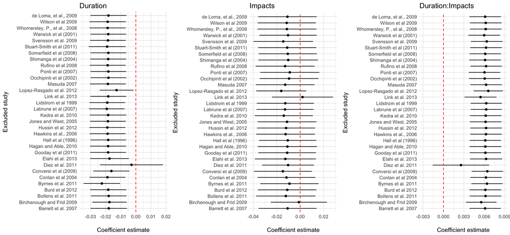

**Figure S4.** Jackknife plots evaluating the influence of studies on the coefficient estimates from the LR ~ Duration + Impacts + Duration:Impacts variance-weighted meta-regression.

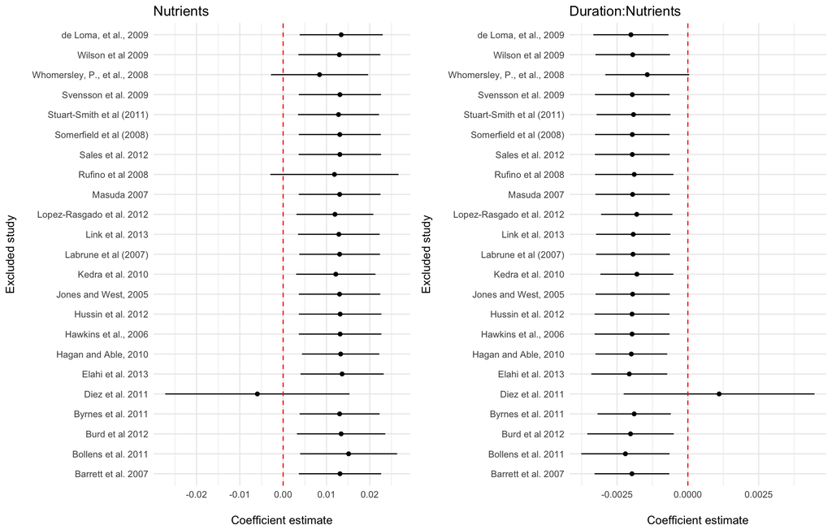

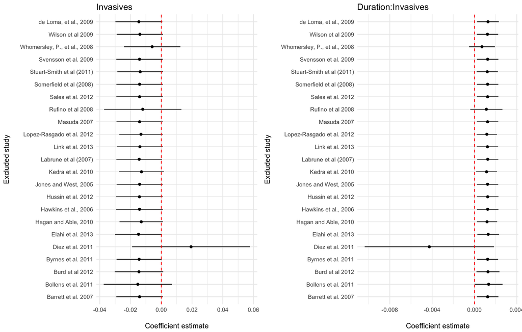

**Figure S6.** Jackknife plots evaluating the influence of studies on the coefficient estimation of invasives alone and the effect of invasives on the rate of change of local richness change in the full driver by duration variance-weighted meta-regression.

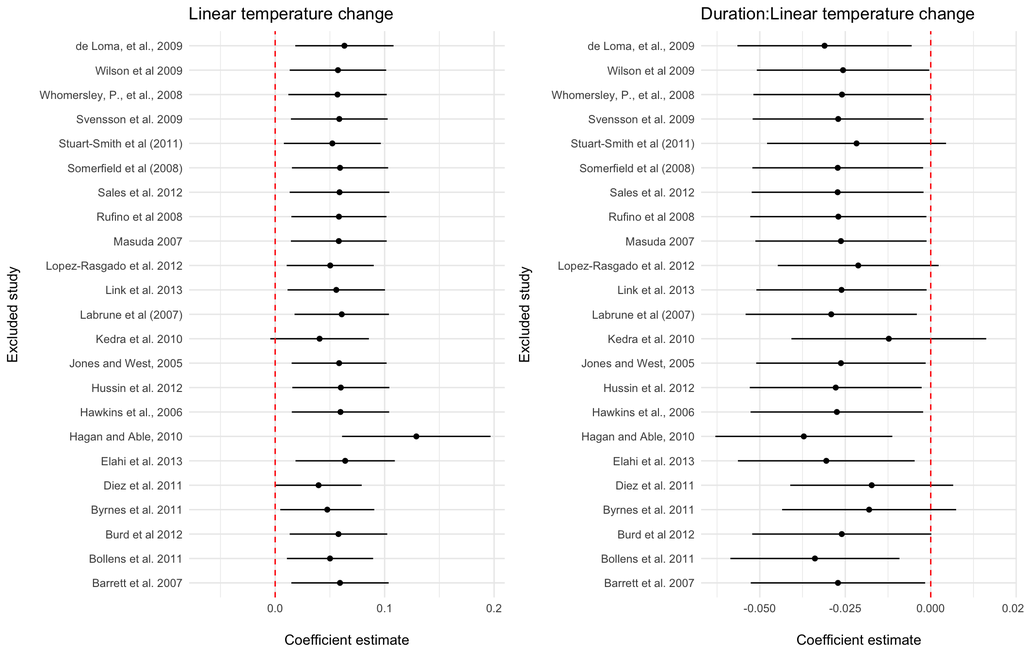

**Table S5** Standardised parameter estimates from three variance-weighted meta-regressions of the log ratio of the proportion of species richness change (LR) that excluded the influential study Diez *et al.* 2011. For each parameter estimate the number of studies (n), number of sites (k), p-value (pval), lower and upper 95% confidence intervals are included. The percent change (% change) has been back-calculated from the estimated log ratio of the proportion of change in species richness. Each study could contain multiple sites and therefore studies were modeled as random effects.

| model | n | k | parameter | estimate | % change | pval | lower CI | upper CI |
| --- | --- | --- | --- | --- | --- | --- | --- | --- |
| LR ~ Dur | 34 | 126 | Int | -0.048 | -4.67 | 0.351 | -0.15 | 0.05 |
|  |  |  | Dur | 0.009 | 0.88 | 0.057 | 0.00 | 0.02 |
| LR ~ CHI + Dur + Dur*CHI | 31 | 115 | Int | 0.139 | 14.89 | 0.348 | -0.15 | 0.43 |
|  |  |  | Dur | -0.018 | -1.76 | 0.352 | -0.06 | 0.02 |
|  |  |  | CHI | -0.036 | -3.51 | 0.224 | -0.09 | 0.02 |
|  |  |  | Dur:CHI | 0.005 | 0.53 | 0.139 | 0.00 | 0.01 |
| LR ~ Dur * (Inv + Nut + LTC) | 22 | 92 | Int | 0.228 | -1.37 | 0.330 | -0.23 | 0.69 |
|  |  |  | Dur | -0.040 | 1.39 | 0.266 | -0.11 | 0.03 |
|  |  |  | Inv | 2.080 | 0.00 | 0.339 | -2.19 | 6.35 |
|  |  |  | LTC | 0.107 | 4.16 | 0.075 | -0.01 | 0.22 |
|  |  |  | Nut | -0.338 | -0.57 | 0.611 | -1.64 | 0.96 |
|  |  |  | Dur:Inv | -0.460 | 0.00 | 0.181 | -1.13 | 0.21 |
|  |  |  | Dur:LTC | -0.048 | -1.84 | 0.146 | -0.11 | 0.02 |
|  |  |  | Dur:Nut | 0.064 | 0.11 | 0.548 | -0.14 | 0.27 |

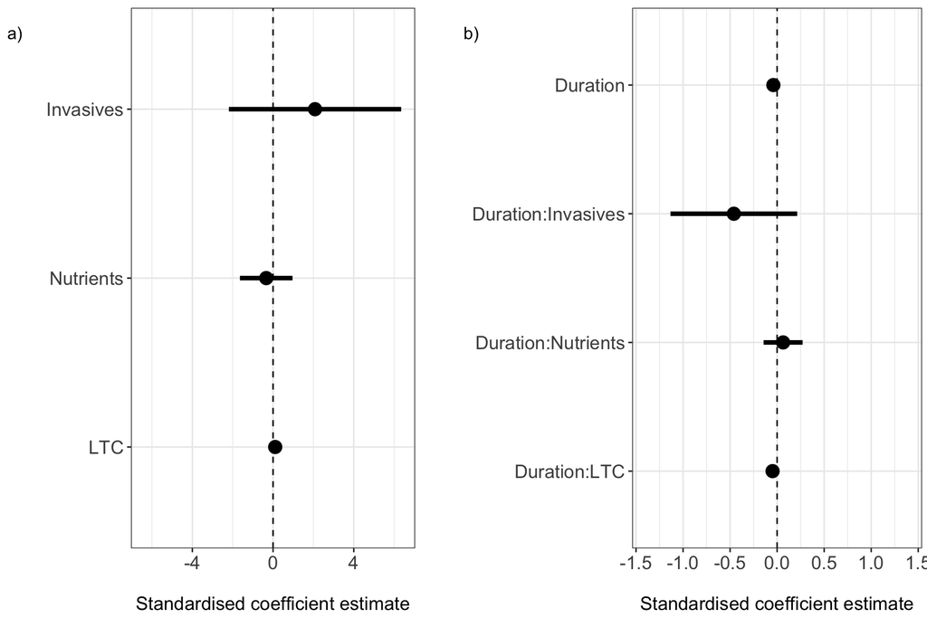

**Figure S8.** The effect, when the influential study Diez *et al.* 2011 was excluded, of three global drivers: propagule pressure (Invasives), decadal rate of linear temperature change (LTC), and nutrient addition (Nutrients) on (a) the log-proportion of change in species richness in the short term and (b) the effect of these drivers on the rate of change in the log-proportion of change in species richness over time. Points represent standardised coefficient estimates and lines represent 95% CI obtained using a variance-weighted meta-regression.

### Distribution of drivers in a global context

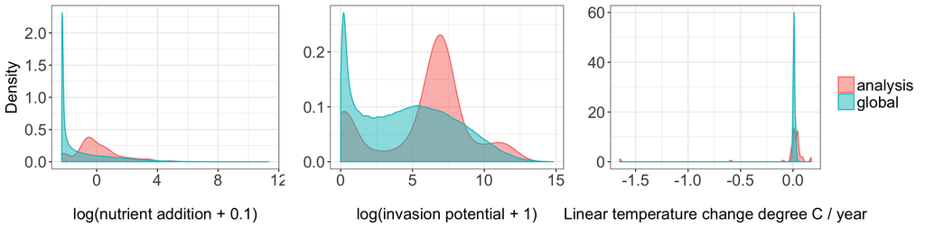

**Figure S9.** The global distribution of drivers (blue) compared to the distribution of drivers observed in our dataset (red) for (a) nutrient addition, (b) propagule pressure, and (c) rate of linear temperature (degree C / year). Values of nutrient addition and propagule pressure were log-transformed to improve visualisation of extreme values. Due to idiosyncrasies in the data layers and because large expanses of coastal areas had no nutrient addition or propagule pressure values greater than zero, zero values in the global drivers were excluded, therefore are under-represented here. To include zero values that were observed in our dataset we added either 0.1 or 1 to the driver values before log-transforming them.

### Unweighted analyses

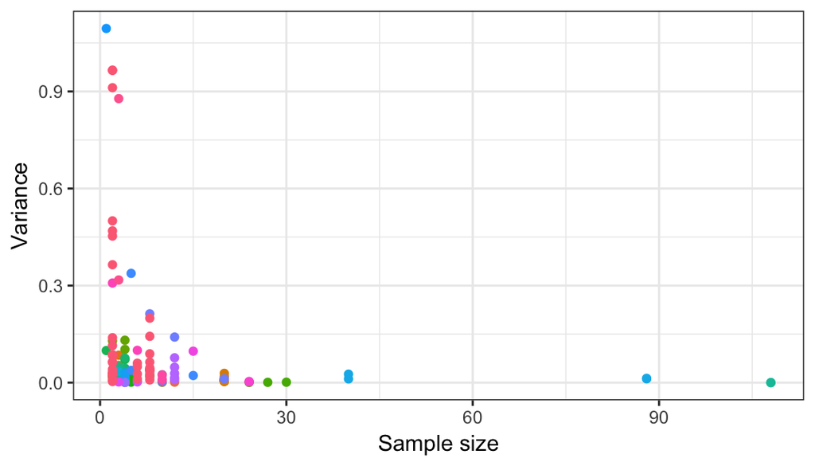

**Table S6.** Comparison of sample sizes used for each of the three models of the log ratio of species richness change performed using: variance-weighted (var-w) meta-regression and unweighted (un-w) regression.

| model | var-w sites | var-w studies | un-w sites | un-w studies |
| --- | --- | --- | --- | --- |
| LR ~ D | 142 | 34 | 502 | 114 |
| LR ~ D * Imp | 133 | 32 | 459 | 105 |
| LR ~ D * (I + N + LTC) | 110 | 23 | 379 | 84 |

| model | n | k | parameter | estimate | % change | pval | lower CI | upper CI |
| --- | --- | --- | --- | --- | --- | --- | --- | --- |
| LR ~ Dur | 114 | 502 | Int | -0.013 | -1.31 | 0.758 | -0.10 | -0.10 |
|  |  |  | Dur | 0.004 | 0.40 | 0.140 | 0.00 | 0.00 |
| LR ~ CHI + Dur + Dur*CHI | 105 | 459 | Int | -0.215 | -19.31 | 0.061 | -0.44 | -0.44 |
|  |  |  | Dur | 0.011 | 1.10 | 0.068 | 0.00 | 0.00 |
|  |  |  | CHI | 0.044 | 4.53 | 0.065 | 0.00 | 0.00 |
|  |  |  | Dur:CHI | -0.002 | -0.15 | 0.206 | 0.00 | 0.00 |
| LR ~ Dur * (Inv + Nut + LTC) | 84 | 379 | Int | 0.007 | 0.29 | 0.886 | -0.09 | -0.09 |
|  |  |  | Dur | 0.004 | 0.20 | 0.256 | 0.00 | 0.00 |
|  |  |  | Inv | 0.036 | 0.03 | 0.840 | -0.31 | -0.31 |
|  |  |  | LTC | 0.003 | 0.12 | 0.934 | -0.07 | -0.07 |
|  |  |  | Nut | -0.006 | -0.01 | 0.961 | -0.25 | -0.25 |
|  |  |  | Dur:Inv | 0.016 | 0.02 | 0.370 | -0.02 | -0.02 |
|  |  |  | Dur:LTC | 0.009 | 0.37 | 0.631 | -0.03 | -0.03 |
|  |  |  | Dur:Nut | 0.003 | 0.01 | 0.774 | -0.02 | -0.02 |

**Table S8.** Standardised parameter estimates from three unweighted regressions of the log ratio of the proportion of species richness change (LR) performed on the same subset of data used in the variance-weighted analysis. Table details are the same as in Table S1.

| model | n | k | parameter | estimate | % change | pval | lower CI | upper CI |
| --- | --- | --- | --- | --- | --- | --- | --- | --- |
| LR ~ Dur | 35 | 144 | Int | -0.058 | -5.64 | 0.429 | -0.20 | -0.20 |
|  |  |  | Dur | 0.013 | 1.28 | 0.049 | 0.00 | 0.00 |
| LR ~ CHI + Dur + Dur*CHI | 32 | 133 | Int | -0.121 | -11.37 | 0.627 | -0.60 | -0.60 |
|  |  |  | Dur | 0.008 | 0.84 | 0.732 | -0.04 | -0.04 |
|  |  |  | CHI | 0.019 | 1.88 | 0.732 | -0.09 | -0.09 |
|  |  |  | Dur:CHI | 0.001 | 0.09 | 0.843 | -0.01 | -0.01 |
| LR ~ Dur * (Inv + Nut + LTC) | 23 | 110 | Int | 0.007 | 0.29 | 0.950 | -0.20 | -0.20 |
|  |  |  | Dur | -0.007 | 0.20 | 0.763 | -0.05 | -0.05 |
|  |  |  | Inv | 0.178 | 0.03 | 0.647 | -0.54 | -0.54 |
|  |  |  | LTC | -0.055 | 0.12 | 0.648 | -0.28 | -0.28 |
|  |  |  | Nut | -0.291 | -0.01 | 0.795 | -2.41 | -2.41 |
|  |  |  | Dur:Inv | -0.007 | 0.02 | 0.791 | -0.06 | -0.06 |
|  |  |  | Dur:LTC | 0.103 | 0.37 | 0.220 | -0.05 | -0.05 |
|  |  |  | Dur:Nut | 0.047 | 0.01 | 0.786 | -0.27 | -0.27 |

#### Appendix 3 - Data Sources

Barrett, N. S., Edgar, G. J., Buxton, C. D., & Haddon, M. (2007). Changes in fish assemblages following 10 years of protection in Tasmanian marine protected areas. Journal of Experimental Marine Biology and Ecology, 345(2), 141-157. doi:10.1016/j.jembe.2007.02.007

Birchenough, S. N. R., & Frid, C. L. J. (2009). Macrobenthic succession following the cessation of sewage sludge disposal. Journal of Sea Research, 62(4), 258-267. doi:10.1016/j.seares.2009.06.004

Bollens, S. M., Breckenridge, J. K., Vanden Hooff, R. C., & Cordell, J. R. (2011). Mesozooplankton of the lower San Francisco Estuary: spatio-temporal patterns, ENSO effects and the prevalence of non-indigenous species. Journal of Plankton Research, 33(9), 1358-1377. doi:10.1093/plankt/fbr034

Burd, B., Bertold, S., & Macdonald, T. (2012). Responses of infaunal composition, biomass and production to discharges from a marine outfall over the past decade. Marine Pollution Bulletin, 64(9), 1837-1852. doi:10.1016/j.marpolbul.2012.06.007

Conlan, K. E., Kim, S. L., Lenihan, H. S., & Oliver, J. S. (2004). Benthic changes during 10 years of organic enrichment by McMurdo Station, Antarctica. Marine Pollution Bulletin, 49(1-2), 43-60. doi:10.1016/j.marpolbul.2004.01.007

Conversi, A., Peluso, T., & Fonda-Umani, S. (2009). Gulf of Trieste: A changing ecosystem. Journal of Geophysical Research, 114(C3). doi:10.1029/2008jc004763 de Loma, TL., Chabanet, P., Ferraris, J., Galzin, R., & Harmelin-Vivien, M. (2009). Long-term spatiotemporal variations in coral-reef fish community structure and fishing at a South Pacific atoll. Aquatic Living Resources, 22(3), 281-290. doi:10.1051/alr/2009037

Díez, I., Muguerza, N., Santolaria, A., Ganzedo, U., & Gorostiaga, J. M. (2012). Seaweed assemblage changes in the eastern Cantabrian Sea and their potential relationship to climate change. Estuarine, Coastal and Shelf Science, 99, 108-120. doi:10.1016/j.ecss.2011.12.027

Elahi, R., Birkeland, C., Sebens, K. P., Turner, K. R., & Dwyer, T. R. (2013). Limited change in the diversity and structure of subtidal communities over four decades. Marine Biology, 160(12), 3209-3219. doi:10.1007/s00227-013-2308-3

Gooday, A. J., Malzone, M. G., Bett, B. J., & Lamont, P. A. (2010). Decadal-scale changes in shallow-infaunal foraminiferal assemblages at the Porcupine Abyssal Plain, NE Atlantic. Deep Sea Research Part II: Topical Studies in Oceanography, 57(15), 1362-1382. doi:10.1016/j.dsr2.2010.01.012

Hagan, S. M., & Able, K. W. (2007). Diel Variation in the Pelagic Fish Assemblage in a Temperate Estuary. Estuaries and Coasts, 31(1), 33-42. doi:10.1007/s12237-007-9018-3

Hall, J. (1996). Effects of metal contamination on macrobenthos of two North Sea estuaries. ICES Journal of Marine Science, 53(6), 1014-1023. doi:10.1006/jmsc.1996.0127

Hawkins, J. P., Roberts, C. M., Dytham, C., Schelten, C., & Nugues, M. M. (2006). Effects of habitat characteristics and sedimentation on performance of marine reserves in St. Lucia. Biological Conservation, 127(4), 487-499. doi:10.1016/j.biocon.2005.09.008

Hoffmeyer, M. S. (2004). Decadal change in zooplankton seasonal succession in the Bahia Blanca estuary, Argentina, following introduction of two zooplankton species. Journal of Plankton Research, 26(2), 181-189. doi:10.1093/plankt/fbh023

Jones, M. V., & West, R. J. (2005). Spatial and temporal variability of seagrass fishes in intermittently closed and open coastal lakes in southeastern Australia. Estuarine, Coastal and Shelf Science, 64(2-3), 277-288. doi:10.1016/j.ecss.2005.02.021

Kędra, M., Włodarska-Kowalczuk, M., & Węsławski, J. M. (2009). Decadal change in macrobenthic soft-bottom community structure in a high Arctic fjord (Kongsfjorden, Svalbard). Polar Biology, 33(1), 1-11. doi:10.1007/s00300-009-0679-1

Labrune, C., Grémare, A., Guizien, K., & Amouroux, J. M. (2007). Long-term comparison of soft bottom macrobenthos in the Bay of Banyuls-sur-Mer (north-western Mediterranean Sea): A reappraisal. Journal of Sea Research, 58(2), 125-143. doi:10.1016/j.seares.2007.02.006

Lindstrom, S. C., Houghton, J. P., & Lees, D. C. (1999). Intertidal Macroalgal Community Structure in Southwestern Prince William Sound, Alaska. Botanica Marina, 42(3). doi:10.1515/bot.1999.030

Link, H., Piepenburg, D., & Archambault, P. (2013). Are Hotspots Always Hotspots? The Relationship between Diversity, Resource and Ecosystem Functions in the Arctic. PLoS ONE, 8(9), e74077. doi:10.1371/journal.pone.0074077 NA

Martin, R. A., Nesbitt, E. A., & Martin, D. E. (2013). Distribution of foraminifera in Puget Sound, Western Washington, USA. The Journal of Foraminiferal Research, 43(3), 291-304.

Masuda, R. (2007). Seasonal and interannual variation of subtidal fish assemblages in Wakasa Bay with reference to the warming trend in the Sea of Japan. Environmental Biology of Fishes, 82(4), 387-399. doi:10.1007/s10641-007-9300-z

Occhipinti-Ambrogi, A., Favruzzo, M., & Savini, D. (2002). Multi-Annual Variations of Macrobenthos along the Emilia-Romagna Coast (Northern Adriatic). Marine Ecology, 23(s1), 307-319. doi:10.1111/j.1439-0485.2002.tb00029.x

Ponti, M., Antonia Colangelo, M., & Ugo Ceccherelli, V. (2007). Composition, biomass and secondary production of the macrobenthic invertebrate assemblages in a coastal lagoon exploited for extensive aquaculture: Valle Smarlacca (northern Adriatic Sea). Estuarine, Coastal and Shelf Science, 75(1-2), 79-89. doi:10.1016/j.ecss.2007.01.021

Rufino, M. M., Gaspar, M. B., Maynou, F., & Monteiro, C. C. (2008). Regional and temporal changes in bivalve diversity off the south coast of Portugal. Estuarine, Coastal and Shelf Science, 80(4), 517-528. doi:10.1016/j.ecss.2008.09.014

Sales, M., & Ballesteros, E. (2012). Seasonal dynamics and annual production of Cystoseira crinita (Fucales: Ochrophyta)-dominated assemblages from the northwestern Mediterranean. Scientia Marina, 76(2), 391-401. doi:10.3989/scimar.03465.16d

Shirayama, Y., Kitazato, H., & Shimanaga, M. (2004). Temporal patterns in diversity and species composition of deep-sea benthic copepods in bathyal Sagami Bay, central Japan. Marine Biology, 144(6), 1097-1110. doi:10.1007/s00227-003-1273-7

Somerfield, P. J., Jaap, W. C., Clarke, K. R., Callahan, M., Hackett, K., Porter, J., Lybolt, M., Tsokos, C., Yanev, G. (2008). Changes in coral reef communities among the Florida Keys, 1996-2003. Coral Reefs, 27(4), 951-965. doi:10.1007/s00338-008-0390-7

Stuart-Smith, R. D., Barrett, N. S., Stevenson, D. G., & Edgar, G. J. (2010). Stability in temperate reef communities over a decadal time scale despite concurrent ocean warming. Global Change Biology, 16(1), 122-134. doi:10.1111/j.1365-2486.2009.01955.x

Svensson, P., Rodwell, L. D., & Attrill, M. J. (2009). Privately managed marine reserves as a mechanism for the conservation of coral reef ecosystems: a case study from Vietnam. AMBIO: A Journal of the Human Environment, 38(2), 72-78.

Wan Hussin, W. M. R., Cooper, K. M., Froján, C. R. S. B., Defew, E. C., & Paterson, D. M. (2012). Impacts of physical disturbance on the recovery of a macrofaunal community: A comparative analysis using traditional and novel approaches. Ecological Indicators, 12(1), 37-45. doi:10.1016/j.ecolind.2011.03.016

Warwick, R.M., Ashman, C.M., Brown, A.R., Clarke, K.R., Dowell, B., Hart, B., Lewis, R.E., Shillabeer, N., Somerfield, J., Tapp, J.F. (2002). Inter-annual changes in the biodiversity and community structure of the macrobenthos in Tees Bay and the Tees estuary, UK, associated with local and regional environmental events. Marine Ecology Progress Series, 234, 1-13. doi:10.3354/meps234001

Whomersley, P., Ware, S., Rees, H. L., Mason, C., Bolam, T., Huxham, M., & Bates, H. (2008). Biological indicators of disturbance at a dredged-material disposal site in Liverpool Bay, UK: an assessment using time-series data. ICES Journal of Marine Science, 65(8), 1414-1420. doi:10.1093/icesjms/fsn125

Wilson, S. K., Dolman, A. M., Cheal, A. J., Emslie, M. J., Pratchett, M. S., & Sweatman, H. P. A. (2008). Maintenance of fish diversity on disturbed coral reefs. Coral Reefs, 28(1), 3-14. doi:10.1007/s00338-008-0431-2

### Literature cited

Díez, I., N. Muguerza, A. Santolaria, U. Ganzedo, and J. M. Gorostiaga. 2012. Seaweed assemblage changes in the eastern Cantabrian Sea and their potential relationship to climate change. Estuarine, Coastal and Shelf Science 99:108-120.

Halpern, B. S., M. Frazier, J. Potapenko, K. S. Casey, K. Koenig, C. Longo, J. S. Lowndes, R. C. Rockwood, E. R. Selig, K. A. Selkoe, and S. Walbridge. 2015. Spatial and temporal changes in cumulative human impacts on the world’s ocean. Nature Communications 6:7615.

Hedges, L. V, J. Gurevitch, and P. S. Curtis. 1999. The meta-analysis of response ratios in experimental ecology. Ecology 80:1150-1156.

Lajeunesse, M.J. 2013 Power statistics for meta-analysis: tests for mean effects and homogeneity. In J. Koricheva, J. Gurevitch, and K. Mengersen, editors. Handbook of meta-analysis in ecology and evolution (pp. 348-363). Princeton University Press, Princeton, New Jersey, USA